# Motor Trend: The Relationship between MPG and Car-related Indicators

Regression Models Course Project

Jan

# Executive Summary

# Data loading

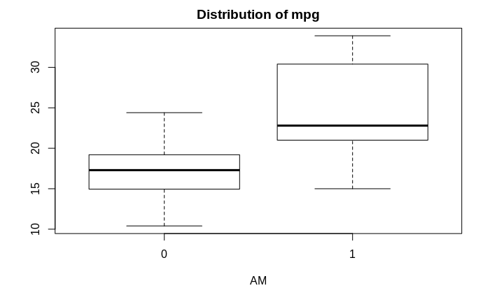

```r
data(mtcars)
boxplot(mpg ~ am, data = mtcars, main = "Distribution of mpg", xlab = "AM")
```

# Data analysis

## Exploratory analysis

- number of different models
- distribution of no. gears and am/m

## Predictive modeling

```r
fit <- lm(mpg ~ am-1, data = mtcars)
summary(fit)
```

```
Call:
lm(formula = mpg ~ am - 1, data = mtcars)

Residuals:
   Min     1Q Median     3Q    Max
-9.392  2.583 13.800 17.875 24.400

Coefficients:
   Estimate Std. Error t value Pr(>|t|)
am   24.392      3.956   6.166 7.67e-07 ***
---
Signif. codes:  0 ‘***’ 0.001 ‘**’ 0.01 ‘*’ 0.05 ‘.’ 0.1 ‘ ’ 1

Residual standard error: 14.26 on 31 degrees of freedom
Multiple R-squared:  0.5508,    Adjusted R-squared:  0.5363
F-statistic: 38.01 on 1 and 31 DF,  p-value: 7.666e-07
```

```r
fit2 <- lm(mpg ~ am, data = mtcars)
summary(fit2)
```

```
Call:
lm(formula = mpg ~ am, data = mtcars)

Residuals:
    Min      1Q  Median      3Q     Max
-9.3923 -3.0923 -0.2974  3.2439  9.5077

Coefficients:
            Estimate Std. Error t value Pr(>|t|)
(Intercept)   17.147      1.125  15.247 1.13e-15 ***
am             7.245      1.764   4.106 0.000285 ***
---
Signif. codes:  0 ‘***’ 0.001 ‘**’ 0.01 ‘*’ 0.05 ‘.’ 0.1 ‘ ’ 1

Residual standard error: 4.902 on 30 degrees of freedom
Multiple R-squared:  0.3598,    Adjusted R-squared:  0.3385
F-statistic: 16.86 on 1 and 30 DF,  p-value: 0.000285
```

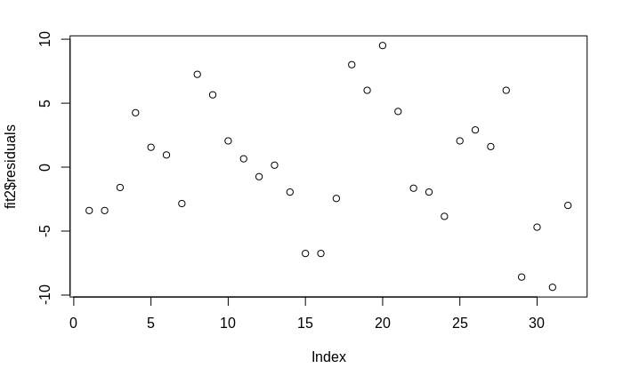

```r
plot(fit2$residuals)
```

# Questions to answer:

You work for Motor Trend, a magazine about the automobile industry. Looking at a data set of a collection of cars, they are interested in exploring the relationship between a set of variables and miles per gallon (MPG) (outcome). They are particularly interested in the following two questions:

- “Is an automatic or manual transmission better for MPG”
- “Quantify the MPG difference between automatic and manual transmissions”

Review criteria:

1. Did the student interpret the coefficients correctly?
2. Did the student do some exploratory data analyses?
3. Did the student fit multiple models and detail their strategy for model selection?
4. Did the student answer the questions of interest or detail why the question(s) is (are) not answerable?
5. Did the student do a residual plot and some diagnostics?
6. Did the student quantify the uncertainty in their conclusions and/or perform an inference correctly?
7. Was the report brief (about 2 pages long) for the main body of the report and no longer than 5 with supporting appendix of figures?
8. Did the report include an executive summary?
9. Was the report done in Rmd (knitr)?